# Data Science Immersive: Data Visualization

Introduction to ggplot2

Rick Scavetta, for Misk Skills

This is the practical component of the **Data Visualization** module of the Misk Skills Data Science Immersive

To use this markdown document, make sure you have installed `ggplot2` (`munsell`, `RColorBrewer` and `Hmisc` should be installed as dependencies). You can click on the knit button to execute all the code and produce an HTML output, which is already provided for you in the files pane to the right.

```r
# load packages, (pre-installed with tidyverse)
library(ggplot2)

# These are not strictly necessary, but we'll use them for looking at some specific examples
library(munsell)
library(RColorBrewer)
library(Hmisc)
```

We’ll begin by looking at accessing colors and then move onto `ggplot2`.

# 1 Using Color

There many packages that provide colour palettes in R. The most widely used and fundamental is `RColorBrewer`. These pallets come from Cynthia Brewer, a cartographer who developed the pallets for her map-making colleagues. They are a good starting point for us and well integrated into ggplot2 and you can find a handy web-site summary [here](https://colorbrewer2.org).

The *sequential* color palettes:

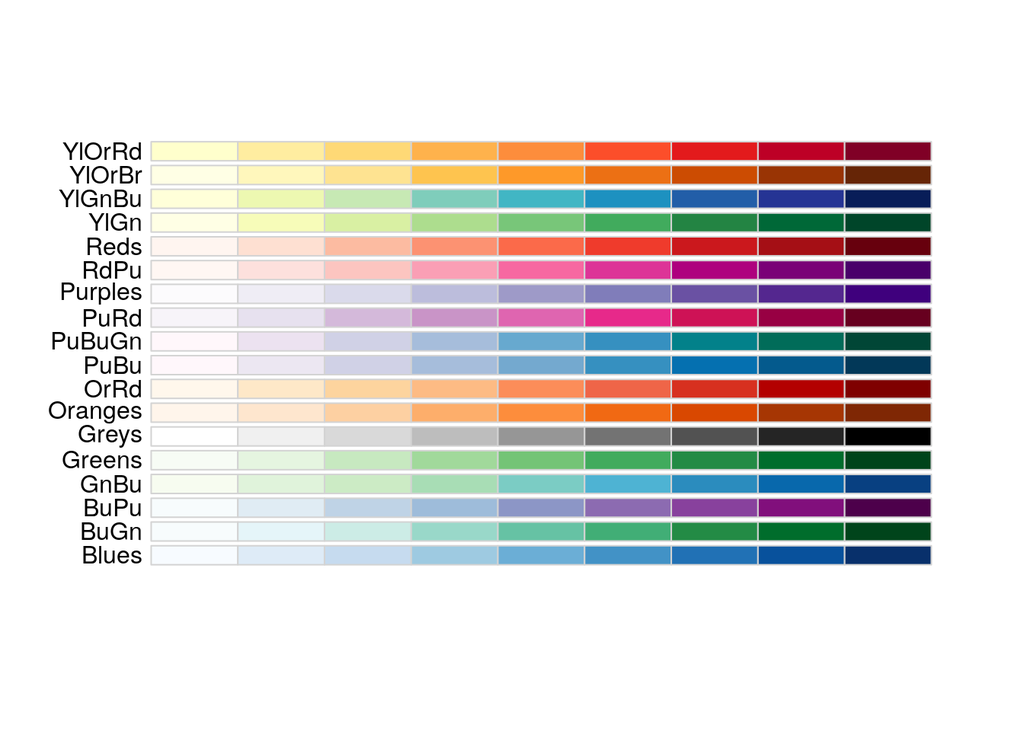

```r
display.brewer.all(type = "seq")
```

The *qualitative* color palettes:

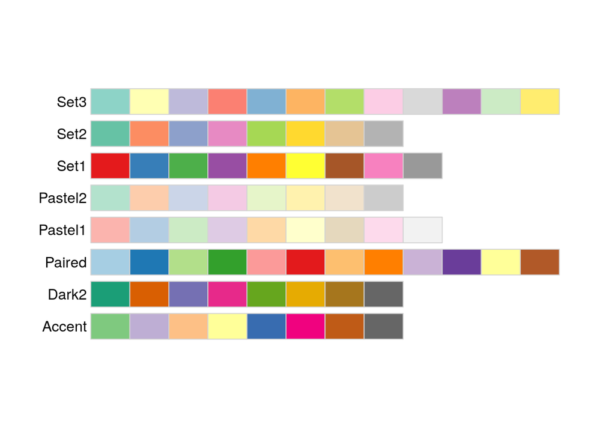

```r
display.brewer.all(type = "qual")
```

The *divergent* color palettes:

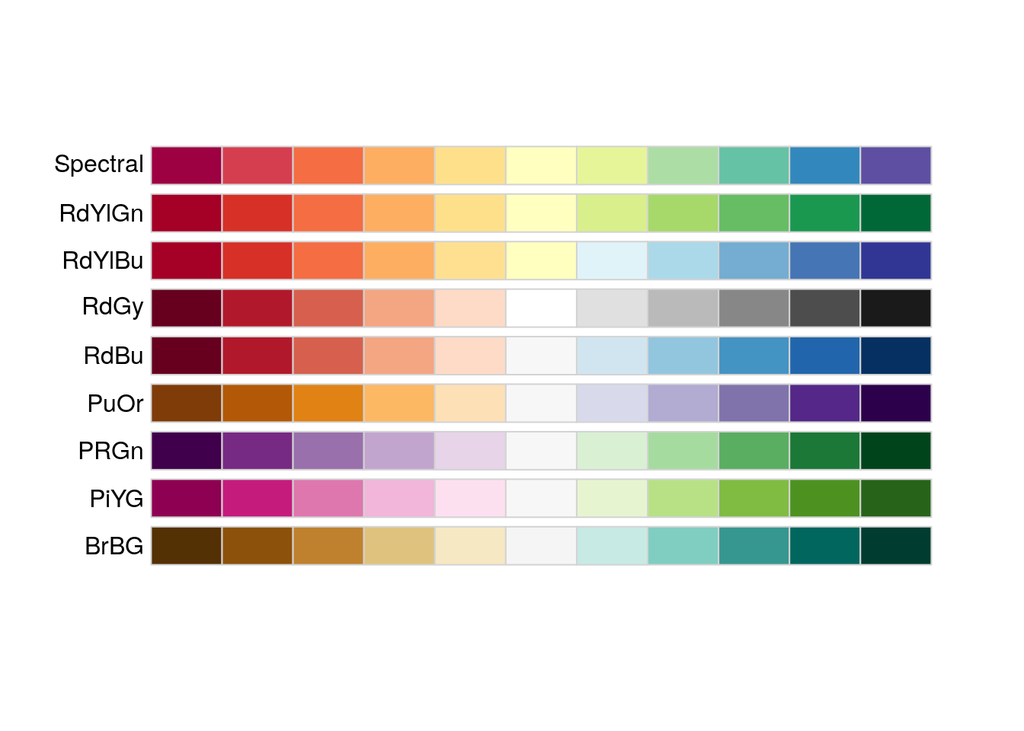

```r
display.brewer.all(type = "div")
```

To view all the available pallets use:

```r
display.brewer.all()
```

To access a given number of colors in a specific pallet use:

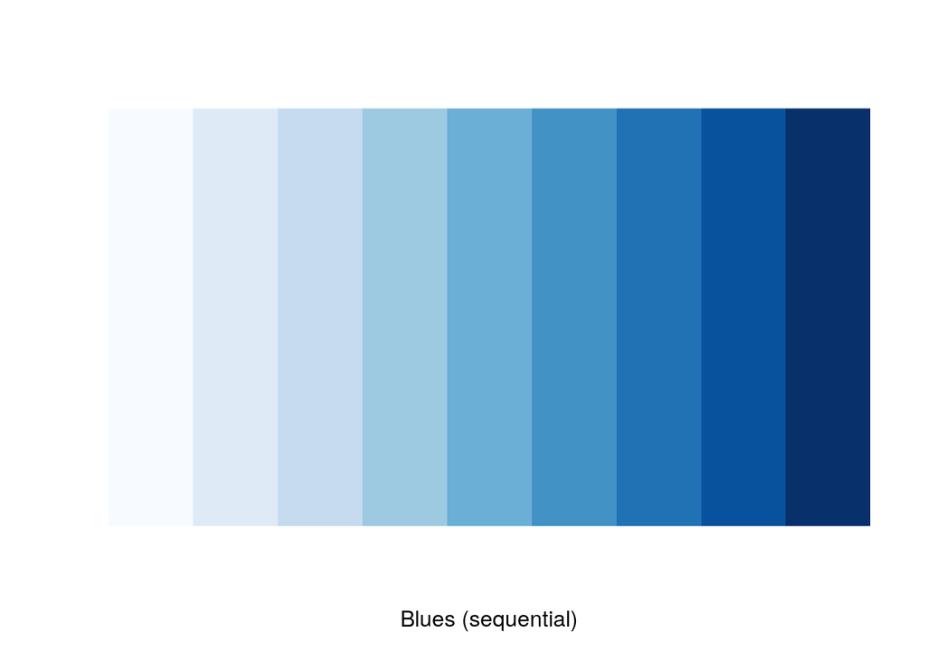

```r
display.brewer.pal(9, "Blues")
```

If you use

```r
brewer.pal(9, "Blues")
```

```
## [1] "#F7FBFF" "#DEEBF7" "#C6DBEF" "#9ECAE1" "#6BAED6" "#4292C6" "#2171B5"
## [8] "#08519C" "#08306B"
```

you’ll get a character vector of the hex codes (discussed in the ebook). Just like any other vector in R, we can index this using `[]`. Here, we’ll just take three shades of blue and assign them to the object `myBlues`.

```r
myBlues <- brewer.pal(9, "Blues")[c(4,6,8)]
```

Once you have these hex codes, You can use them in all and graphics to maintain consistency in your color palette across your presentation or paper. If you want to view what colour the hex code is, the munsell package has a really nice function:

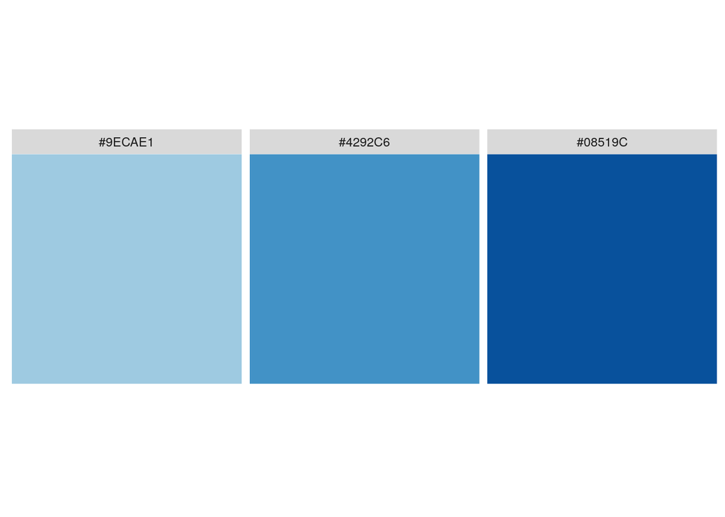

```r
plot_hex(myBlues)
```

# 2 ggplot2: The first three essential layers

Now that we have an idea of how to obtain color values, let’s dig into `ggplot2`. In the case studies I presented `ggplot2` as being comprised of seven layers.

## 2.1 Layer 1: The data layer

I discussed the data layer in the first case study looking at peppermint sugar content. We need each variable on our plot to be its own variable in our data site.

There are many built in datasets in R. A really good starting point for understanding `ggplot2` is the `mtcars` data set. It describes the properties of 32 engines from cars in 1973. The *mt* in `mtcars` stands for *Motor Trends*, a magazine that apparently was ahead of the game in providing detailed engine metrics.

The dataset contains the following variables:

| Variable | Description |
| --- | --- |
| mpg | Miles/(US) gallon |
| cyl | Number of cylinders |
| disp | Displacement (cu.in.) |
| hp | Gross horsepower |
| drat | Rear axle ratio |
| wt | Weight (1000 lbs) |
| qsec | 1/4 mile time |
| vs | Engine (0 = V-shaped, 1 = straight) |
| am | Transmission (0 = automatic, 1 = manual) |
| gear | Number of forward gears |
| carb | Number of carburetors |

You can access the dataset directly from base package.

```r
mtcars
```

```
##                      mpg cyl  disp  hp drat    wt  qsec vs am gear carb
## Mazda RX4           21.0   6 160.0 110 3.90 2.620 16.46  0  1    4    4
## Mazda RX4 Wag       21.0   6 160.0 110 3.90 2.875 17.02  0  1    4    4
## Datsun 710          22.8   4 108.0  93 3.85 2.320 18.61  1  1    4    1
## Hornet 4 Drive      21.4   6 258.0 110 3.08 3.215 19.44  1  0    3    1
## Hornet Sportabout   18.7   8 360.0 175 3.15 3.440 17.02  0  0    3    2
## Valiant             18.1   6 225.0 105 2.76 3.460 20.22  1  0    3    1
## Duster 360          14.3   8 360.0 245 3.21 3.570 15.84  0  0    3    4
## Merc 240D           24.4   4 146.7  62 3.69 3.190 20.00  1  0    4    2
## Merc 230            22.8   4 140.8  95 3.92 3.150 22.90  1  0    4    2
## Merc 280            19.2   6 167.6 123 3.92 3.440 18.30  1  0    4    4
## Merc 280C           17.8   6 167.6 123 3.92 3.440 18.90  1  0    4    4
## Merc 450SE          16.4   8 275.8 180 3.07 4.070 17.40  0  0    3    3
## Merc 450SL          17.3   8 275.8 180 3.07 3.730 17.60  0  0    3    3
## Merc 450SLC         15.2   8 275.8 180 3.07 3.780 18.00  0  0    3    3
## Cadillac Fleetwood  10.4   8 472.0 205 2.93 5.250 17.98  0  0    3    4
## Lincoln Continental 10.4   8 460.0 215 3.00 5.424 17.82  0  0    3    4
## Chrysler Imperial   14.7   8 440.0 230 3.23 5.345 17.42  0  0    3    4
## Fiat 128            32.4   4  78.7  66 4.08 2.200 19.47  1  1    4    1
## Honda Civic         30.4   4  75.7  52 4.93 1.615 18.52  1  1    4    2
## Toyota Corolla      33.9   4  71.1  65 4.22 1.835 19.90  1  1    4    1
## Toyota Corona       21.5   4 120.1  97 3.70 2.465 20.01  1  0    3    1
## Dodge Challenger    15.5   8 318.0 150 2.76 3.520 16.87  0  0    3    2
## AMC Javelin         15.2   8 304.0 150 3.15 3.435 17.30  0  0    3    2
## Camaro Z28          13.3   8 350.0 245 3.73 3.840 15.41  0  0    3    4
## Pontiac Firebird    19.2   8 400.0 175 3.08 3.845 17.05  0  0    3    2
## Fiat X1-9           27.3   4  79.0  66 4.08 1.935 18.90  1  1    4    1
## Porsche 914-2       26.0   4 120.3  91 4.43 2.140 16.70  0  1    5    2
## Lotus Europa        30.4   4  95.1 113 3.77 1.513 16.90  1  1    5    2
## Ford Pantera L      15.8   8 351.0 264 4.22 3.170 14.50  0  1    5    4
## Ferrari Dino        19.7   6 145.0 175 3.62 2.770 15.50  0  1    5    6
## Maserati Bora       15.0   8 301.0 335 3.54 3.570 14.60  0  1    5    8
## Volvo 142E          21.4   4 121.0 109 4.11 2.780 18.60  1  1    4    2
```

## 2.2 Layers 2: Aesthetics

The second essential layer is the aesthetics layer. In the course, we referred to these as the *encoding* elements. Other names for aesthetics are *scales* or *axes*. e.g. we typically refer to the X axis, but there are many other aesthetics which work in the same way. Let’s begin with the X and Y axes.

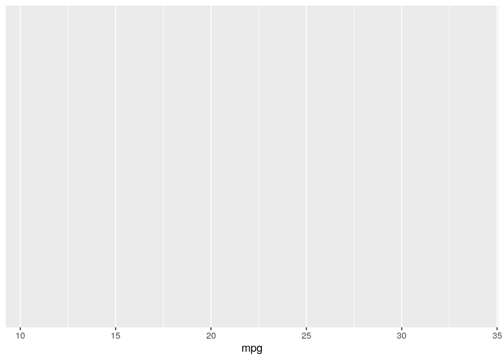

```r
# Univariate plot - Histogram
ggplot(mtcars, aes(x = mpg))
```

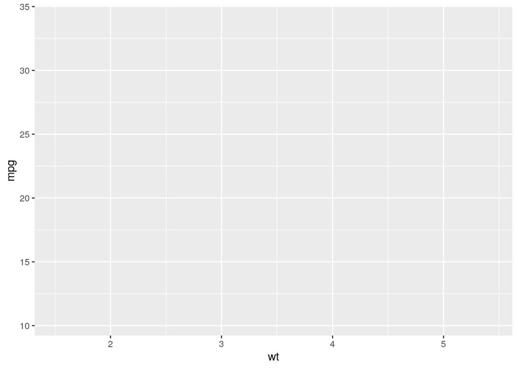

```r
# Bi-/Multi-variate plot - Scatter plot
ggplot(mtcars, aes(x = wt, y = mpg))
```

Notice that in the above plots, we have *literally* what we ask for: a histogram with an X axis and a scatter plot with X and Y axes. There are no visuals, i.e. geometries, since they need to be added as a separate layer. We’ll get to that soon.

The first arguments of `aes()` are `x` and `y`, so we’ll typically leave them out. Other common aesthetics are:

- `color`
  - Also, `colour`
- `fill`
- `shape`
- `size`
- `linetype`

You’ll often see `color` called as as `col`, using partial name matching, to call the argument. I tend to do this, but it’s a bad habit. The best practice is to call the entire name.

## 2.3 Layers 3: Geometries

The third essential layer is the geometries layer. Here we specify what we actually want to see. You’ll see that the naming convention of the functions in `ggplot2` are very well organized! All the geometries have the form `geom_*()`. You can see a list by typing `geom_` in an R script document and pressing tab for auto complete. There are currently 48 geometries:

| geom_* |  |  |  |  |  |  |
| --- | --- | --- | --- | --- | --- | --- |
| abline | contour | dotplot | jitter | pointrange | ribbon | spoke |
| area | count | errorbar | label | polygon | rug | step |
| bar | crossbar | errorbarh | line | qq | segment | text |
| bin2d | curve | freqpoly | linerange | qq_line | sf | tile |
| blank | density | hex | map | quantile | sf_label | violin |
| boxplot | density2d | histogram | path | raster | sf_text | vline |
| col | density_2d | hline | point | rect | smooth |  |

For example, to make a histogram, we’ll use:

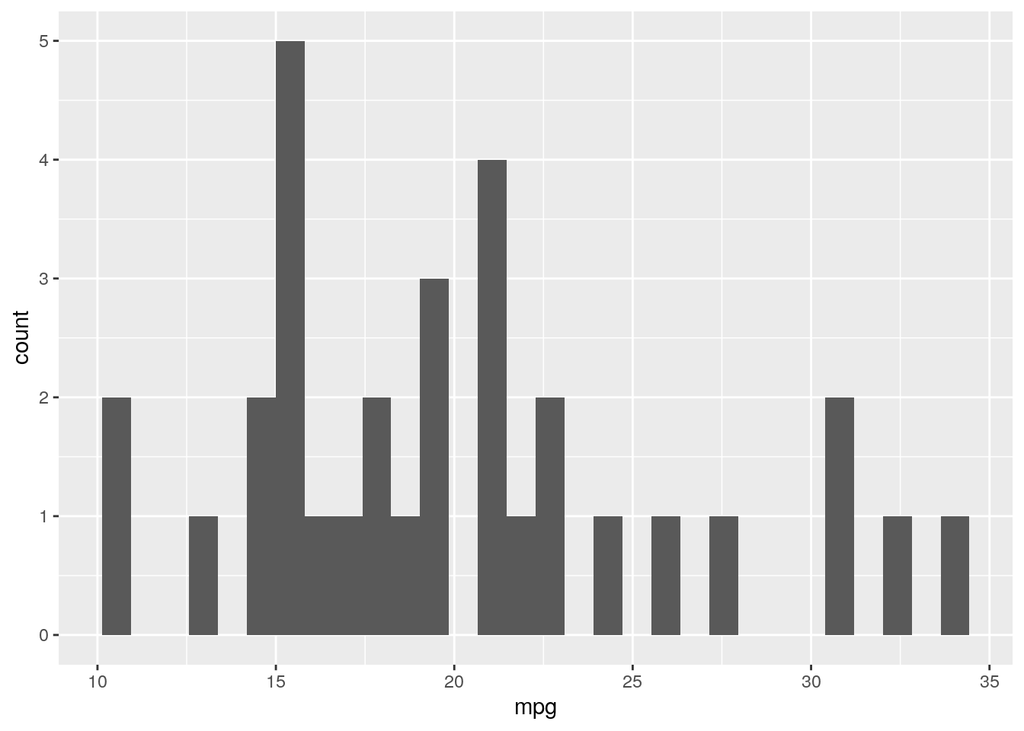

```r
# Univariate plot - Histogram
ggplot(mtcars, aes(mpg)) +
  geom_histogram()
```

But for scatter plots, there is no scatter plot geom. We just need to have continuous X and Y axes and apply a point geom layer:

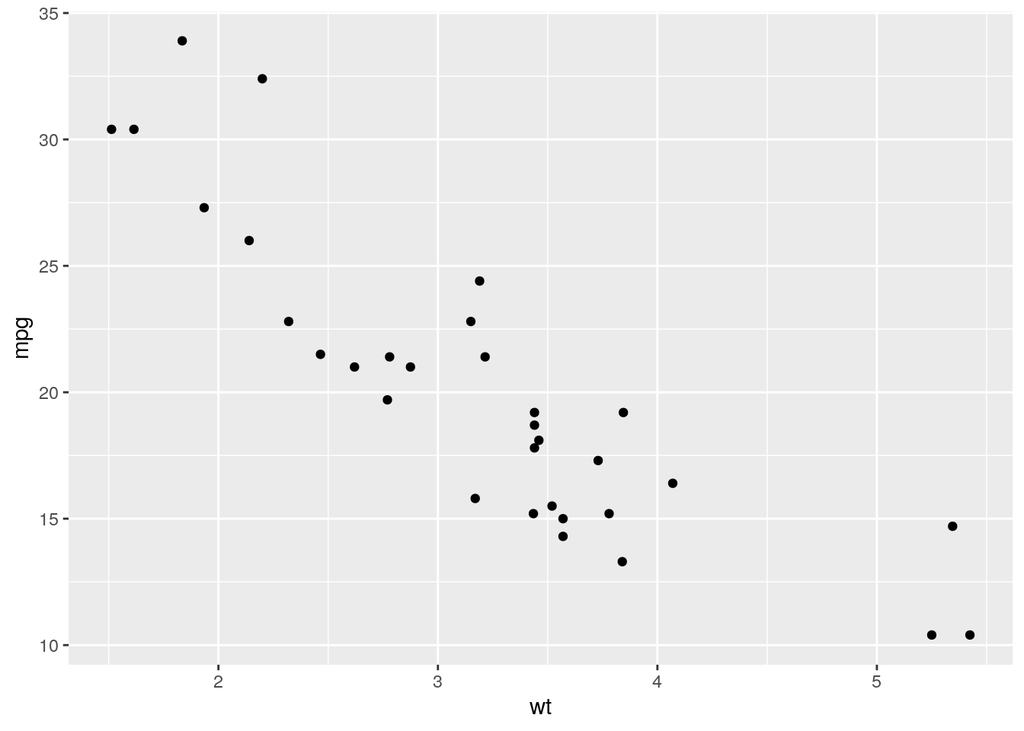

```r
# Bi-/Multi-variate plot - Scatter plot
ggplot(mtcars, aes(wt, mpg)) +
  geom_point()
```

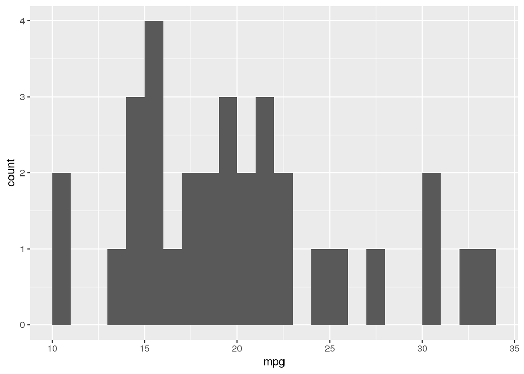

```r
# Univariate plot - Histogram
ggplot(mtcars, aes(mpg)) +
  geom_histogram(binwidth = 1, boundary = 1)
```

For the scatter plots, we may want to adjust the geom’s *attributes*:

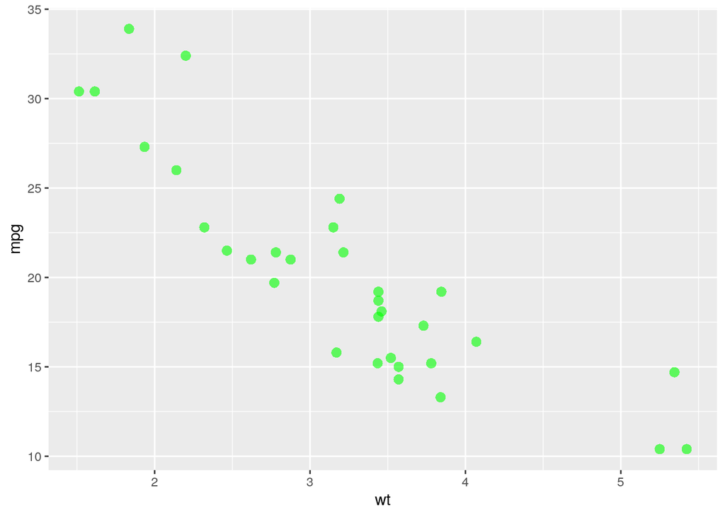

```r
# Bi-/Multi-variate plot - Scatter plot
ggplot(mtcars, aes(wt, mpg)) +
  geom_point(
    shape = 16,
    alpha = 0.6,
    size = 3,
    # fill = "pink"
    color = "green"
  )
```

The first argument, `shape` specifies the *shape* to use, as a built-in R integer code. I find that the most common & useful values for the `shape` argument are:

[output not shown]

The `fill` aesthetic and attribute typically refers to the *inside* of a geometry, as we’ll see later. However, An exception to the rule is with points. Here, we typically use the `color` aesthetic, except in the case where a circle has an outline which we see in shape `21`.

Recall that *alpha* refers to transparency. For `alpha`, `1` = 100% opaque and `0` = 0% opaque (i.e. 100% transparent). I typically use a value between 0.3 - 0.7.

The `size` argument adjusts the points size.

Returning to our discussion of over-plotting in the video course, in this case I would use the above corrections (solid, slightly transparent points) *or* I would go with hollow, opaque points.

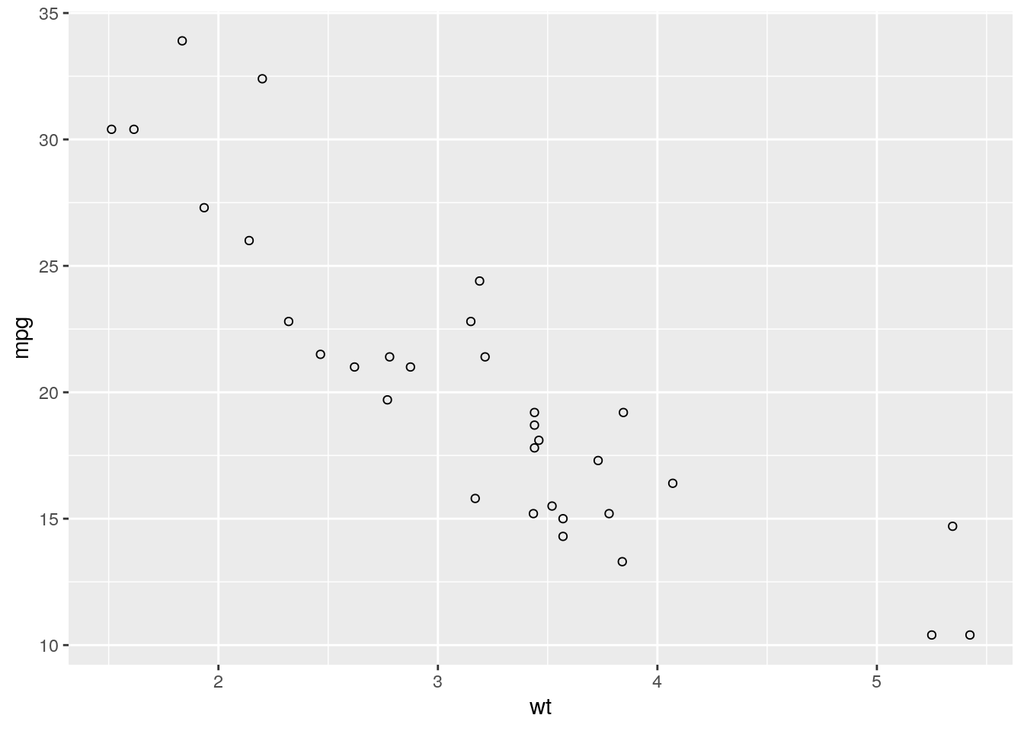

```r
# Bi-/Multi-variate plot - Scatter plot
ggplot(mtcars, aes(wt, mpg)) +
  geom_point(shape = 1)
```

These argument names are the same names as the *aesthetics* I mentioned earlier! This is common point of confusion, so note the distinction between:

- **Aesthetics**, which are arguments in the aesthetics layer, defined inside `aes()`, and are used to *map* a variable onto a scale, and
- **Attributes**, which are arguments in the geom later, and are used to *set* a value.

The terms *scale*, *aesthetic*, and *axis* are commonly used interchangeably, but at specific points in making the plot, so don’t let this confuse you.

Let’s add another aesthetic to see what I mean:

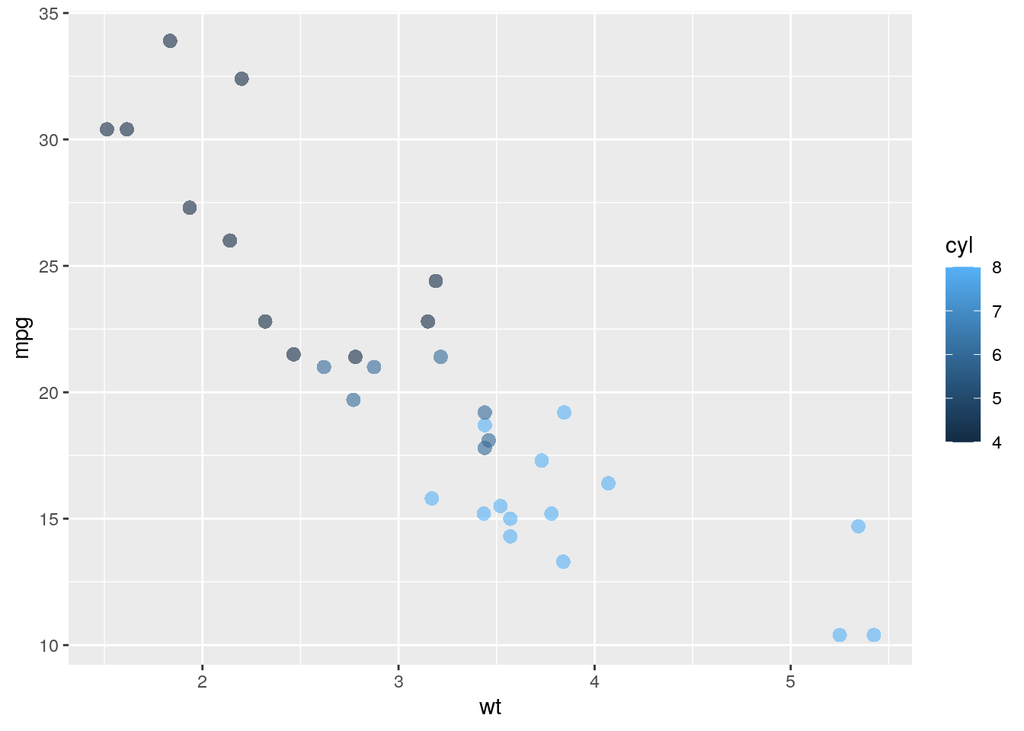

```r
# Bi-/Multi-variate plot - Scatter plot
ggplot(mtcars, aes(wt, mpg, color = cyl)) +
  geom_point(shape = 16, alpha = 0.6,
             size = 3)
```

The points are now colored according to `cyl`, i.e. we *mapped* `cyl` onto `color`. Unfortunately, it’s the wrong colour scale. It’s a sequential, continuous color scale, but should be a qualitative color scale. You may recall from the data analysis class that categorical variables are defined as factors in R. We can set this on the fly in our plot.

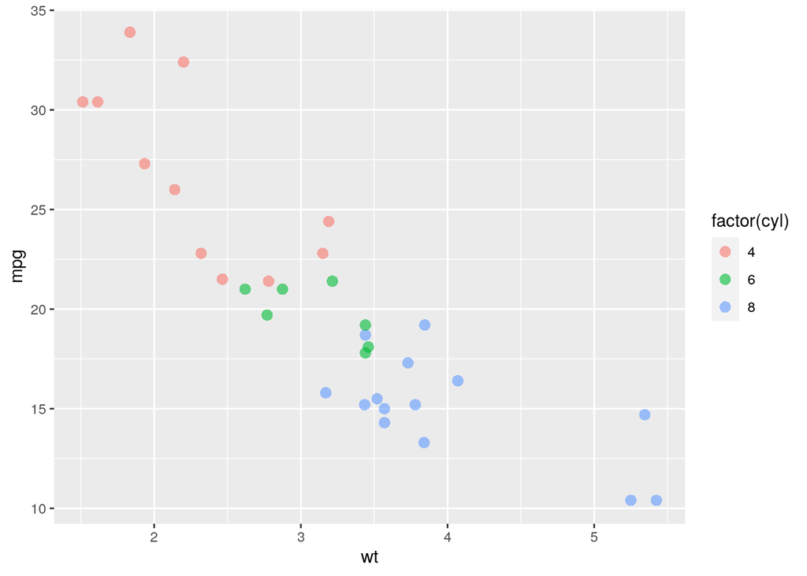

```r
# Bi-/Multi-variate plot - Scatter plot
ggplot(mtcars, aes(wt, mpg, col = factor(cyl))) +
  geom_point(shape = 16, alpha = 0.6,
             size = 3)
```

That’s better. We’ll change it permanently in the dataset later on.

So what happens if we set a colour aesthetic *and* a colour attribute?

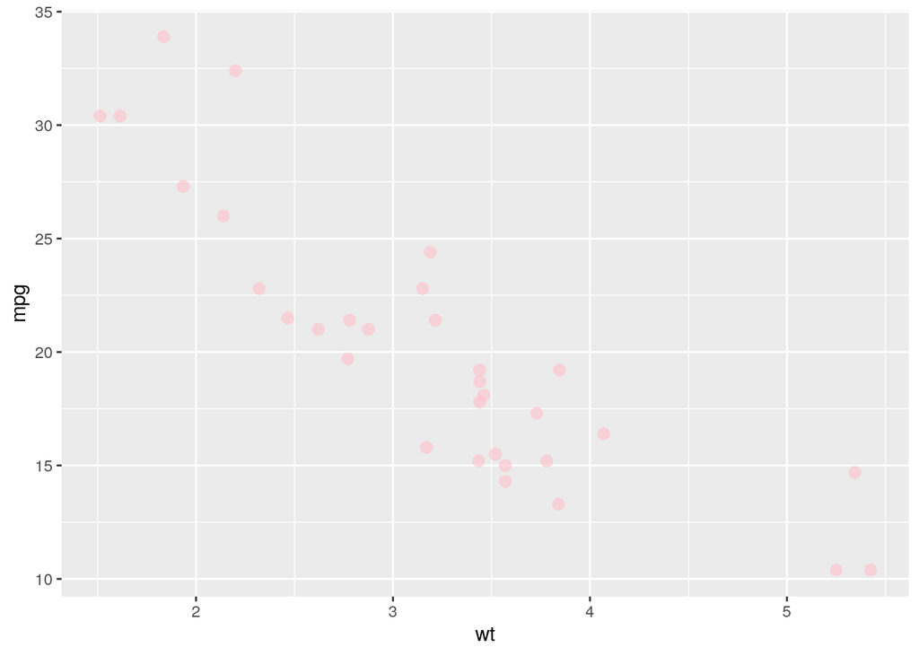

```r
# Bi-/Multi-variate plot - Scatter plot
ggplot(mtcars, aes(wt, mpg, col = factor(cyl))) +
  geom_point(shape = 16, alpha = 0.6,
             size = 3, color = "pink")
```

Attributes beat out aesthetics! This is another really common problem, but if we are aware of this behavior we can use it to good effect.

## 2.4 Positions

So far our plots have used position “identity”, Which means don’t do anything, just put the geometry exactly where the data says to put it. That’s the default for `geom_point()`, which kind of makes sense. But that doesn’t make sense for things like bar plots.

Let’s take a look. Our goal is to make a plot of this contigency table. It tells us the number of counts for each transmission (`am`) type, 0 & 1, in each cylinder (`cyl`) class, 4, 6, & 8.

```r
table(mtcars$am, mtcars$cyl)
```

```
##
##      4  6  8
##   0  3  4 12
##   1  8  3  2
```

Remember, `ggplot2` requires a dataframe as input, so we may be tempted to convert the above table to a dataframe. We have the raw values, but what we want to plot is the absolute count of the number of observations. We could calculate the number of observations in each group ourselves, but we can just let ggplot2 do all of that for us.

We’re going to make a couple versions of this plot, so I’m going to assign the data and aesthetics layers to an object, called `g`. You’ll see this a lot in ggplot2 programming. Sometimes the object names are one letter long, which is typically pretty bad style but somehow people get away with it in this case, mostly for the sake of convenience. Typical letters are `g`, `p`, & `q`. Although I’m introducing this concept here, since it makes this example convenient, I want to emphasize that you **do not** need to do this when just making a single plot. It has lots of very useful applications for when your code gets more complicated. You’ll see it in help pages and tutorials, so it’s good to be aware of this practice.

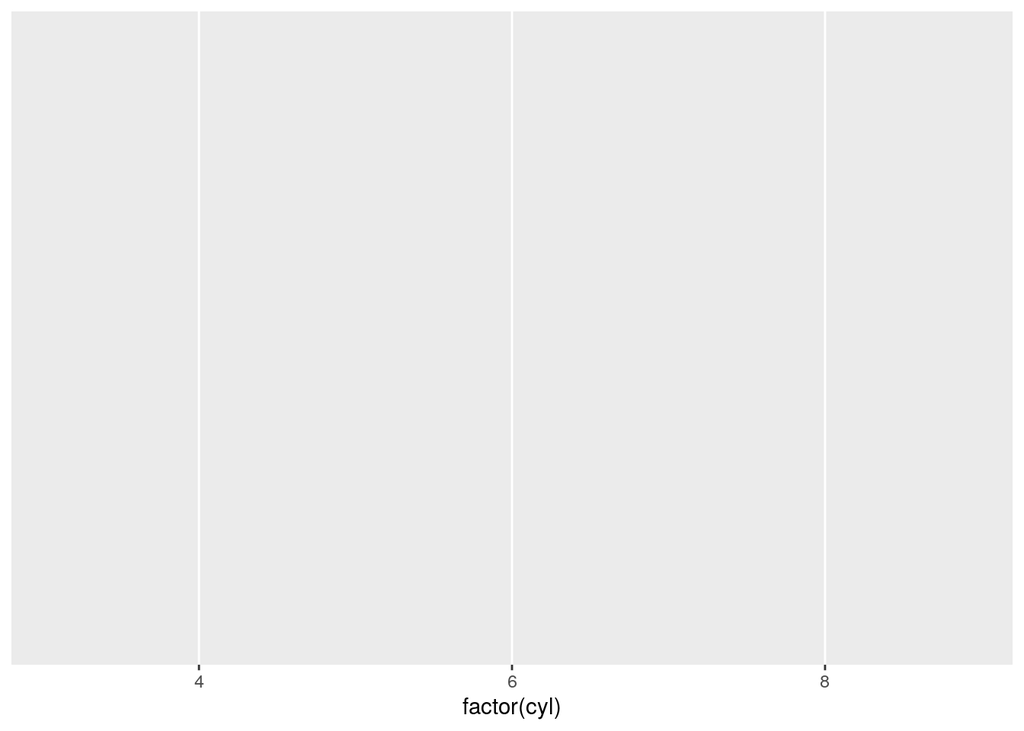

```r
# base layers
g <- ggplot(mtcars, aes(factor(cyl), fill = factor(am)))

g
```

`geom_bar()` will apply a count statistic to our data, which is basically what `table()` did.

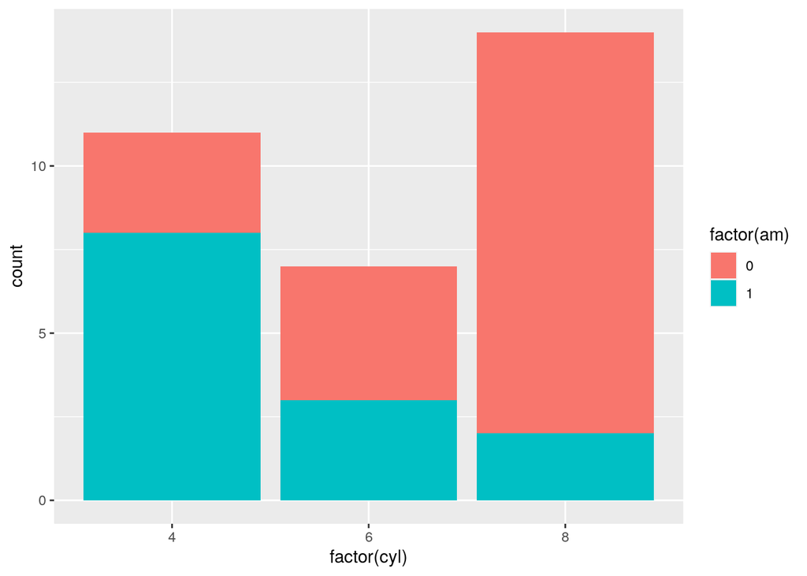

```r
# Default bar plot
g +
  geom_bar()
```

The default position is `"stack"`, which can be specified as:

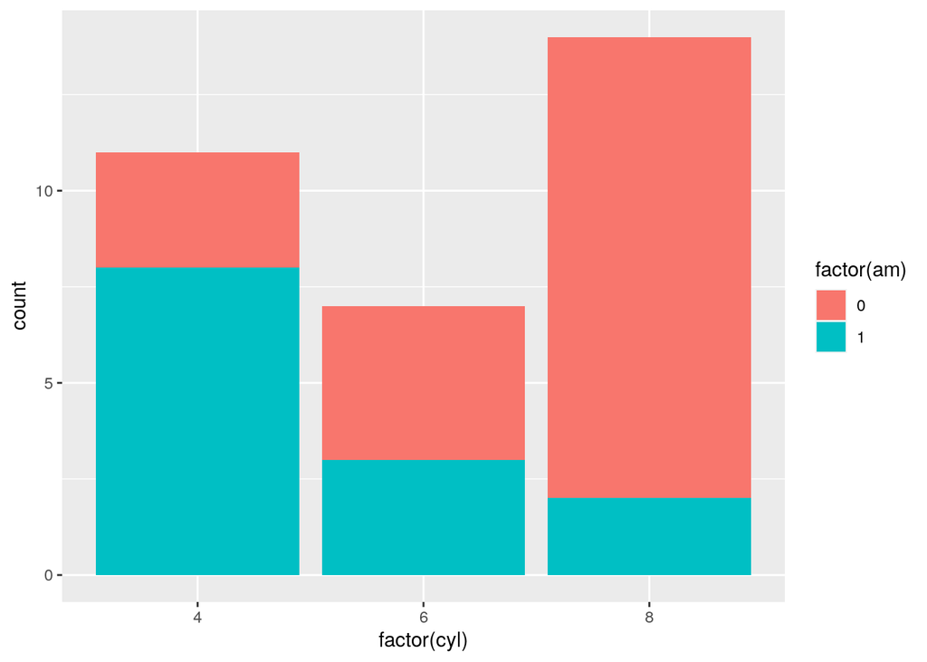

```r
# Which is...
g +
  geom_bar(position = "stack")
```